# Sports Analytics Project

## Data Visualization for Analytics

### Anna Reschko

Professor: Dr. Shiju Zhang

STAT 660

June 2026

## Introduction

The National Basketball Association (NBA) is the highest level of professional basketball in the United States. This project analyzes player statistics using a dataset containing season-level information for NBA players between the 1996–97 and 2021–22 seasons.

The dataset was filtered to include only the 2005–06 through 2021–22 seasons. Five research questions were selected to examine different aspects of NBA performance and league development, including age and performance, scoring trends, international representation, rookie impact, and player efficiency. The analysis was conducted in R using data analytics and data visualizations to identify patterns and trends in the data.

## Data

The analysis uses the NBA Players Dataset, which contains season level statistics for NBA players from the 1996–97 through the 2021–22 seasons. The dataset includes 12,844 observations and 22 variables, with each observation representing a player’s performance during a single NBA season.

The dataset contains demographic variables such as player age, height, weight, college, country of birth, and draft information, as well as performance statistics including games played, points, rebounds, assists, net rating, usage percentage, true shooting percentage, and assist percentage. For this project, only observations from the 2005–06 through the 2021–22 seasons were included in the analysis.

Preview of NBA Players Dataset

| player_name | age | season | country | pts | reb | ast | net_rating |
| --- | --- | --- | --- | --- | --- | --- | --- |
| Tyronn Lue | 29 | 2005-06 | USA | 11.0 | 1.6 | 3.1 | -2.9 |
| T.J. Ford | 23 | 2005-06 | USA | 12.2 | 4.3 | 6.6 | -0.4 |
| Tayshaun Prince | 26 | 2005-06 | USA | 14.1 | 4.2 | 2.3 | 12.0 |
| Terence Morris | 27 | 2005-06 | USA | 1.6 | 1.7 | 0.2 | -0.8 |
| Theo Ratliff | 33 | 2005-06 | USA | 4.9 | 5.1 | 0.5 | -8.9 |
| Tim Duncan | 30 | 2005-06 | US Virgin Islands | 18.6 | 11.0 | 3.2 | 9.5 |

## Results

### Question 1 - Age and Player Performance

Players aged 27–30 recorded the highest average performance across all three measures, with the highest averages in points, rebounds, and assists. Performance remained relatively high for players aged 31–34, but declined after age 35. Players over 40 years old recorded the lowest averages in all three statistics. Overall, the results suggest that NBA players typically reach their peak performance during their late twenties before gradually declining with age.

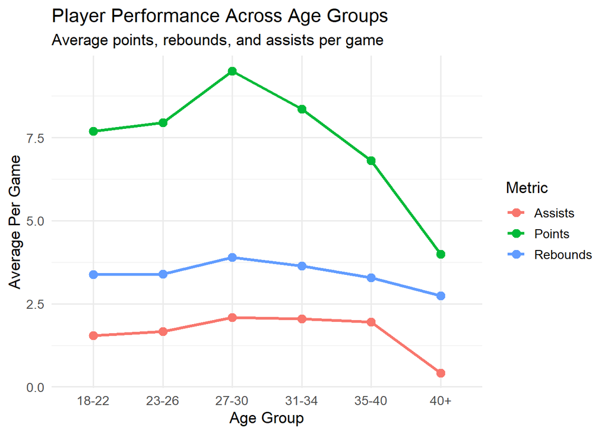

### Question 2 - Scoring Trends Across NBA Seasons

Kobe Bryant was the league’s leading scorer in both the 2005–06 and 2006–07 seasons, averaging 35.4 and 31.6 points per game, respectively. After a decline in scoring between 2010 and 2015, scoring averages increased again, reaching a peak of 36.1 points per game by James Harden in the 2018–19 season. Kevin Durant led the league in scoring four times, while Russell Westbrook, Stephen Curry, and James Harden each appeared multiple times. Overall, the results indicate that top scorers consistently averaged between 28 and 36 points per game, with scoring generally increasing during the later seasons.

Top Scorer in Each NBA Season

| season | player_name | pts |
| --- | --- | --- |
| 2005-06 | Kobe Bryant | 35.4 |
| 2006-07 | Kobe Bryant | 31.6 |
| 2007-08 | LeBron James | 30.0 |
| 2008-09 | Dwyane Wade | 30.2 |
| 2009-10 | Kevin Durant | 30.1 |
| 2010-11 | Kevin Durant | 27.7 |
| 2011-12 | Kevin Durant | 28.0 |
| 2012-13 | Carmelo Anthony | 28.7 |
| 2013-14 | Kevin Durant | 32.0 |
| 2014-15 | Russell Westbrook | 28.1 |
| 2015-16 | Stephen Curry | 30.1 |
| 2016-17 | Russell Westbrook | 31.6 |
| 2017-18 | James Harden | 30.4 |
| 2018-19 | James Harden | 36.1 |
| 2019-20 | James Harden | 34.3 |
| 2020-21 | Stephen Curry | 32.0 |
| 2021-22 | Joel Embiid | 30.6 |

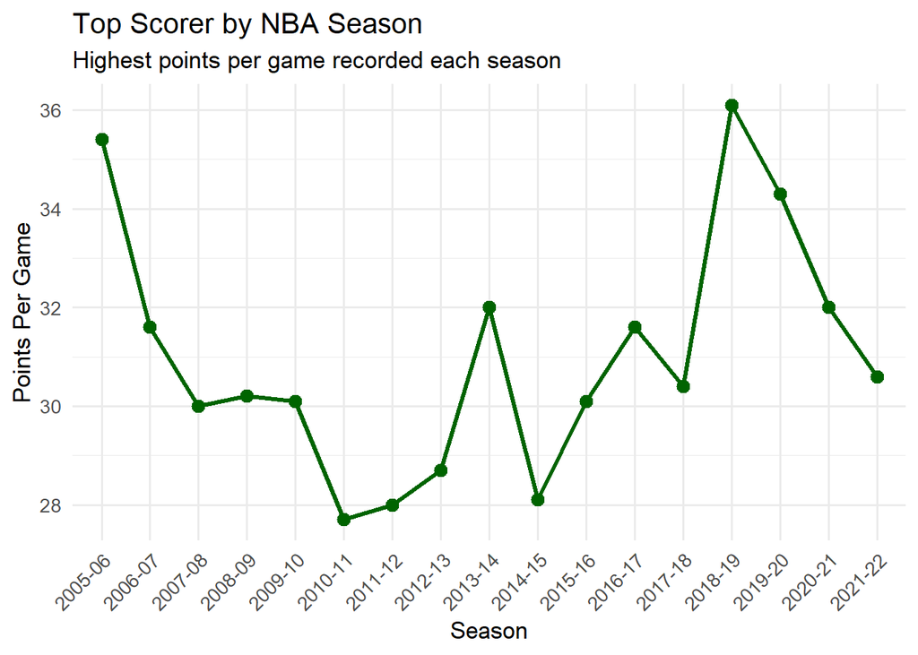

### Question 3: International Representation in the NBA

The number of both USA and international players increased between the 2005–06 and 2021–22 seasons. Throughout the period, USA players continued to make up the majority of the league, increasing from approximately 380 to nearly 470 players. At the same time, the number of international players grew from around 80 to more than 130 players. Overall, the results indicate that while the NBA remains dominated by USA players, international representation has steadily increased over time.

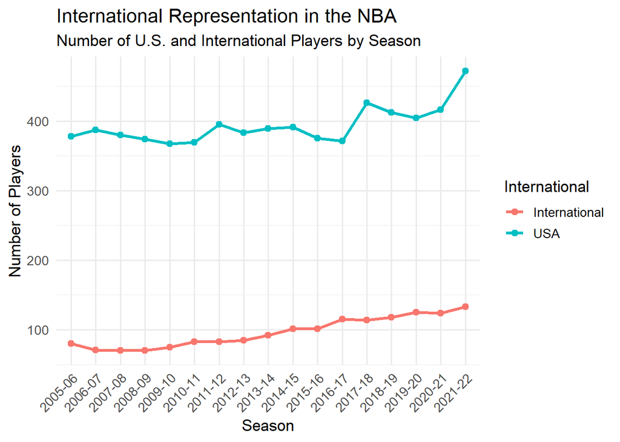

### Question 4 - Rookie Impact and Prime-Year Performance

Prime-age players (27–30 years old) outperformed rookies across all three performance measures. On average, prime players scored 10.6 points, 4.3 rebounds, and 2.3 assists per game, compared with 5.7 points, 2.6 rebounds, and 1.2 assists for rookies. The largest difference was observed in scoring, where prime players averaged almost five more points per game.

Despite the lower average performance of rookies, several first-year players showed an exceptional performance for their teams. Zion Williamson recorded the highest rookie scoring average with 22.5 points per game during the 2019–20 season, followed by Luka Dončić with 21.2 points per game in 2018–19. Other outstanding rookie seasons included Donovan Mitchell, Kevin Durant, and Tyreke Evans, all of whom averaged more than 20 points per game in their first NBA season.

Average Performance of Rookies and Prime-Age Players

| Player_Group | Metric | Average |
| --- | --- | --- |
| Prime (27-30) | Points | 10.592460 |
| Prime (27-30) | Rebounds | 4.263121 |
| Prime (27-30) | Assists | 2.288428 |
| Rookie | Points | 5.705750 |
| Rookie | Rebounds | 2.591500 |
| Rookie | Assists | 1.200750 |

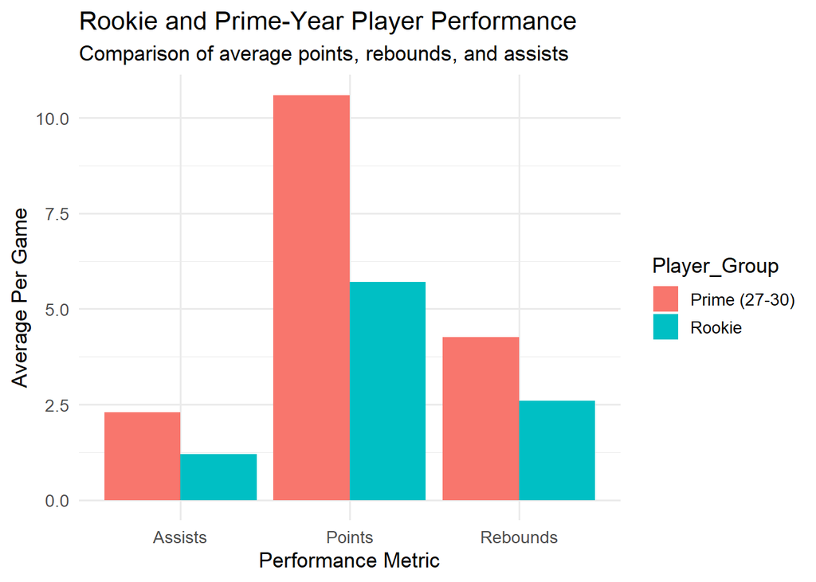

Top Rookie Seasons by Points per Game

| season | player_name | pts | reb | ast |
| --- | --- | --- | --- | --- |
| 2019-20 | Zion Williamson | 22.5 | 6.3 | 2.1 |
| 2018-19 | Luka Doncic | 21.2 | 7.8 | 6.0 |
| 2017-18 | Donovan Mitchell | 20.5 | 3.7 | 3.7 |
| 2007-08 | Kevin Durant | 20.3 | 4.4 | 2.4 |
| 2009-10 | Tyreke Evans | 20.1 | 5.3 | 5.8 |

### Question 5 - Player Efficiency Using Net Rating

Average net rating remained relatively stable across the 2005–06 to 2021–22 seasons, with no clear long-term trend in player efficiency. Table 5 shows the players with the highest average net ratings among those who played at least eight seasons. Manu Ginóbili recorded the highest average net rating (10.12), followed by Kawhi Leonard (9.60) and Tim Duncan (9.05). Overall, the results suggest that net rating is a useful measure for evaluating player efficiency and identifying consistently high-performing players.

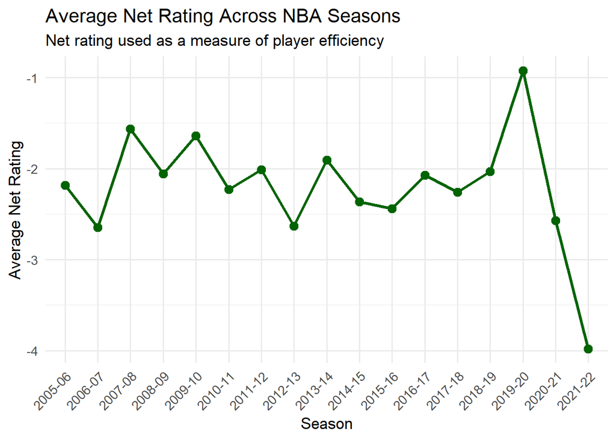

Players with the Highest Average Net Rating (Minimum 8 Seasons)

| player_name | Seasons | Average_Net_Rating |
| --- | --- | --- |
| Manu Ginobili | 13 | 10.12 |
| Kawhi Leonard | 10 | 9.60 |
| Tim Duncan | 11 | 9.05 |
| Draymond Green | 10 | 8.03 |
| Klay Thompson | 9 | 7.82 |
| LeBron James | 17 | 7.53 |
| Chris Paul | 17 | 7.41 |
| Danny Green | 13 | 7.35 |
| Stephen Curry | 13 | 7.13 |
| Tony Parker | 14 | 6.80 |

## Conclusion

This project analyzed NBA player performance using data from the 2005–06 through 2021–22 seasons. The results showed that players generally reached their peak performance between the ages of 27 and 30, while rookie players performed below prime-age players on average despite several exceptional rookie seasons. Scoring trends varied over time, with James Harden recording the highest scoring average in the dataset. The analysis also showed that the number of international players increased steadily, reflecting the NBA’s growing global presence. Finally, net rating remained relatively stable across seasons and proved to be a useful measure for evaluating player efficiency and identifying consistently high performing players.

## Appendix

Data was sourced from:

- Cirtautas, J. (2023). NBA Players [Data set]. Kaggle. https://www.kaggle.com/datasets/justinas/nba-players-data

All code used in this project was written in R and is visible below.

### Code for Project Setup and Data Preparation:

```r
# Load Libraries
library(readr)
library(tidyverse)
library(knitr)
library(kableExtra)
library(ggplot2)
library(scales)
```

```r
nba <- read_csv("all_seasons.csv")

nba_2005_2021 <- nba |>
  filter(season >= "2005-06", season <= "2021-22")

knitr::kable(
  head(nba_2005_2021 |>
         select(player_name, age, season, country, pts, reb, ast, net_rating)),
  caption = "Preview of NBA Players Dataset"
)
```

### Code for Question Results:

```r
# Question 1: Age and Player Performance

nba_2005_2021 |>
  mutate(
    Age_Group = cut(
      age,
      breaks = c(17, 22, 26, 30, 34, 40, Inf),
      labels = c("18-22", "23-26", "27-30", "31-34", "35-40", "40+"),
      include.lowest = TRUE
    )
  ) |>
  filter(!is.na(Age_Group)) |>
  group_by(Age_Group) |>
  summarise(
    Points = mean(pts, na.rm = TRUE),
    Rebounds = mean(reb, na.rm = TRUE),
    Assists = mean(ast, na.rm = TRUE)
  ) |>
  pivot_longer(
    cols = c(Points, Rebounds, Assists),
    names_to = "Metric",
    values_to = "Average"
  ) |>
  ggplot(aes(x = Age_Group,
             y = Average,
             color = Metric,
             group = Metric)) +
  geom_line(linewidth = 1.2) +
  geom_point(size = 3) +
  labs(
    title = "Player Performance Across Age Groups",
    subtitle = "Average points, rebounds, and assists per game",
    x = "Age Group",
    y = "Average Per Game"
  ) +
  theme_minimal(base_size = 13)
```

```r
# Question 2: Scoring Trends Across NBA Seasons

top_scorers <- nba_2005_2021 |>
  group_by(season) |>
  slice_max(pts, n = 1, with_ties = FALSE) |>
  ungroup()

knitr::kable(
  top_scorers |>
    select(season, player_name, pts),
  caption = "Top Scorer in Each NBA Season"
)

ggplot(top_scorers,
       aes(x = season,
           y = pts,
           group = 1)) +
  geom_line(linewidth = 1.2,
            color = "darkgreen") +
  geom_point(size = 3,
             color = "darkgreen") +
  labs(
    title = "Top Scorer by NBA Season",
    subtitle = "Highest points per game recorded each season",
    x = "Season",
    y = "Points Per Game"
  ) +
  theme_minimal(base_size = 13) +
  theme(
    axis.text.x = element_text(angle = 45,
                               hjust = 1)
  )
```

```r
# Question 3: International Representation in the NBA


international_players <- nba_2005_2021 |>
  mutate(
    International = ifelse(country == "USA",
                           "USA",
                           "International")
  ) |>
  group_by(season, International) |>
  summarise(
    Players = n_distinct(player_name),
    .groups = "drop"
  )

ggplot(international_players,
       aes(x = season,
           y = Players,
           color = International,
           group = International)) +
  geom_line(linewidth = 1.2) +
  geom_point(size = 2) +
  labs(
    title = "International Representation in the NBA",
    subtitle = "Number of U.S. and International Players by Season",
    x = "Season",
    y = "Number of Players"
  ) +
  theme_minimal(base_size = 13) +
  theme(
    axis.text.x = element_text(angle = 45, hjust = 1)
  )
```

```r
# Question 4: Rookie Impact and Prime-Year Performance

# Compare average performance of rookies and prime-age players
rookie_prime <- nba_2005_2021 |>
  filter(draft_year != "Undrafted") |>
  mutate(
    Player_Group = case_when(
      season == paste0(
        draft_year,
        "-",
        substr(as.character(as.numeric(draft_year) + 1), 3, 4)
      ) ~ "Rookie",
      age >= 27 & age <= 30 ~ "Prime (27-30)",
      TRUE ~ NA_character_
    )
  ) |>
  filter(!is.na(Player_Group)) |>
  group_by(Player_Group) |>
  summarise(
    Points = mean(pts, na.rm = TRUE),
    Rebounds = mean(reb, na.rm = TRUE),
    Assists = mean(ast, na.rm = TRUE)
  ) |>
  pivot_longer(
    cols = c(Points, Rebounds, Assists),
    names_to = "Metric",
    values_to = "Average"
  )

knitr::kable(
  rookie_prime,
  caption = "Average Performance of Rookies and Prime-Age Players"
)

ggplot(
  rookie_prime,
  aes(x = Metric,
      y = Average,
      fill = Player_Group)
) +
  geom_col(position = "dodge") +
  labs(
    title = "Rookie and Prime-Year Player Performance",
    subtitle = "Comparison of average points, rebounds, and assists",
    x = "Performance Metric",
    y = "Average Per Game"
  ) +
  theme_minimal(base_size = 13)

# Top rookie seasons by points per game
rookie_players <- nba_2005_2021 |>
  filter(draft_year != "Undrafted") |>
  mutate(
    Rookie = season == paste0(
      draft_year,
      "-",
      substr(as.character(as.numeric(draft_year) + 1), 3, 4)
    )
  ) |>
  filter(Rookie) |>
  slice_max(pts, n = 5) |>
  select(season, player_name, pts, reb, ast)

knitr::kable(
  rookie_players,
  caption = "Top Rookie Seasons by Points per Game"
)
```

```r
net_rating_by_season <- nba_2005_2021 |>
  group_by(season) |>
  summarise(
    avg_net_rating = mean(net_rating, na.rm = TRUE)
  )

ggplot(net_rating_by_season,
       aes(x = season,
           y = avg_net_rating,
           group = 1)) +
  geom_line(
    linewidth = 1.2,
    color = "darkgreen"
  ) +
  geom_point(
    size = 3,
    color = "darkgreen"
  ) +
  labs(
    title = "Average Net Rating Across NBA Seasons",
    subtitle = "Net rating used as a measure of player efficiency",
    x = "Season",
    y = "Average Net Rating"
  ) +
  theme_minimal(base_size = 13) +
  theme(
    axis.text.x = element_text(
      angle = 45,
      hjust = 1
    )
  )

# Players with the highest average net rating
top_net_players <- nba_2005_2021 |>
  group_by(player_name) |>
  summarise(
    Seasons = n(),
    Average_Net_Rating = mean(net_rating, na.rm = TRUE),
    .groups = "drop"
  ) |>
  filter(Seasons >= 8) |>
  arrange(desc(Average_Net_Rating)) |>
  slice_head(n = 10)

knitr::kable(
  top_net_players,
  digits = 2,
  caption = "Players with the Highest Average Net Rating (Minimum 8 Seasons)"
)
```